# WeightLiftingExercise

SE_CPT

7th January 2021

## Introduction

As part of the Data Science Specialisation run by JHU on Coursera the Practical Machine Learning module asks trainees to analyse some data on weight lifting exercises - specifically “unilateral dumbbell biceps curl”. The data includes the correct manner of completing the exercise “A” and four common mistakes “B, C, D & E”.

The task is to predict how well people carry out the weight lifting exercise and categorise which method was used.

> **Data Citation:** Velloso, E.; Bulling, A.; Gellersen, H.; Ugulino, W.; Fuks, H. Qualitative Activity Recognition of Weight Lifting >Exercises. Proceedings of 4th International Conference in Cooperation with SIGCHI (Augmented Human ’13) . >Stuttgart, Germany: ACM SIGCHI, 2013.

> Read more: http://groupware.les.inf.puc-rio.br/har

## Load Libraries

Load the libraries necessary to run the code.

```r
## Load relevant libraries
library(caret)
```

```r
library(ggplot2)
library(viridisLite)
```

## Import data

Reading the data from the source and importing it into training and testing datasets.

```r
## Download data
myurl1 <- "https://d396qusza40orc.cloudfront.net/predmachlearn/pml-training.csv"
myurl2 <- "https://d396qusza40orc.cloudfront.net/predmachlearn/pml-testing.csv"
download.file(myurl1,"file1.csv")
download.file(myurl2,"file2.csv")
## Read the raw data
traindata <- read.csv("file1.csv")
testdata <- read.csv("file2.csv") # for test purposes only - don't touch until end
```

## Partition Data

To enable testing of the model against a subset of the original training data a partition was created.  
This will allow cross-validation to be carried out and information about the accuracy of the model to be gathered.

```r
## Partition Data for testing and training
set.seed(32343)
inTrain <- createDataPartition(y = traindata$classe,
                               p = 0.75,
                               list = FALSE) ## 75% for training
training <- traindata[inTrain,]
testing <- traindata[-inTrain,]
```

## Explore Data

Exploration of the data is important to allow decisions about cleaning data and how to model it later. I will only explore the subset of the data I have set aside for training.

```r
## Explore data to allow decisions to be made
dim(training)
str(training)
```

```
## [1] 14718   160
## 'data.frame':    14718 obs. of  160 variables:
##  $ X                       : int  1 2 3 5 6 7 8 10 11 12 ...
##  $ user_name               : Factor w/ 6 levels "adelmo","carlitos",..: 2 2 2 2 2 2 2 2 2 2 ...
##  $ raw_timestamp_part_1    : int  1323084231 1323084231 1323084231 1323084232 1323084232 1323084232 1323084232 1323084232 1323084232 1323084232 ...
##  $ raw_timestamp_part_2    : int  788290 808298 820366 196328 304277 368296 440390 484434 500302 528316 ...
##  $ cvtd_timestamp          : Factor w/ 20 levels "02/12/2011 13:32",..: 9 9 9 9 9 9 9 9 9 9 ...
##  $ new_window              : Factor w/ 2 levels "no","yes": 1 1 1 1 1 1 1 1 1 1 ...
##  $ num_window              : int  11 11 11 12 12 12 12 12 12 12 ...
##  $ roll_belt               : num  1.41 1.41 1.42 1.48 1.45 1.42 1.42 1.45 1.45 1.43 ...
##  $ pitch_belt              : num  8.07 8.07 8.07 8.07 8.06 8.09 8.13 8.17 8.18 8.18 ...
##  $ yaw_belt                : num  -94.4 -94.4 -94.4 -94.4 -94.4 -94.4 -94.4 -94.4 -94.4 -94.4 ...
##  $ total_accel_belt        : int  3 3 3 3 3 3 3 3 3 3 ...
##  $ kurtosis_roll_belt      : Factor w/ 397 levels "","-0.016850",..: 1 1 1 1 1 1 1 1 1 1 ...
##  $ kurtosis_picth_belt     : Factor w/ 317 levels "","-0.021887",..: 1 1 1 1 1 1 1 1 1 1 ...
```

[output cut: 87 more lines]

## Clean Data

Following the exploration it was clear some variables had NA values. I decided to remove columns with NAs in if the total number of NAs in the column exceeded 95% of the length of the column as it wouldn’t be possible to substitute data in this case. Following this I did an assessment to remove any variables that had nearly no effect. This helped reduce the size of the dataset before creating a model.

```r
## Check and remove NAs if more than 95% of total column
cNames <- names(training)  # find column names
na <- 0
ratio <- 0
kill <- 0
tot <- length(training$max_roll_belt)
for (n in 1:(length(cNames)-1))
{
  na[n] <- sum(is.na(training[,n]))
  ratio[n] <- na[n]/tot

  if (ratio[n] > 0.95) {
    kill[n] <- n
  } else {
    kill[n] <- NA
  }
}
killoff <- na.omit(kill)
cleanData <- training[,-killoff]

## Remove variables with nearly no effect from training set
nsv <- nearZeroVar(cleanData,
                   saveMetrics = FALSE)
cutTraining <- cleanData[,-nsv]
```

## Modeling

The method used to train the model to predict the classes was “gbm” Stochastic Gradient Boosting. The method was applied to the clean training dataset. The first 6 columns of the data were excluded from the prediction factors as I didn’t want to base the model on the names of the participants or the time at which the exercises were done. No further pre-processing was carried out.

Then cross-validation was carried out against the subset of testing data that is 25% of the original training data provided. A confusion matrix is created and data gathered to enable the confusion matrices to be plotted later.

```r
## Train model
modelFit <- train(classe ~ .,
                  method = "gbm",
                  data = cutTraining[-c(1:6)],
                  verbose = FALSE)

## Cross Validation
predictionGMB <- predict(modelFit,
                 testing)
## Out of sample
testing$predRight <- predictionGMB==testing$classe
table(testing$predRight)

## Plotting data
data <- data.frame(table(predictionGMB,
                         testing$classe))
dataPerCent <- data.frame(prop.table(table(predictionGMB,
                                           testing$classe), 2))
## Confusion matrix
cm <- confusionMatrix(predictionGMB,
                      testing$classe)
cm
```

```
##
## FALSE  TRUE
##   195  4709
## Confusion Matrix and Statistics
##
##           Reference
## Prediction    A    B    C    D    E
##          A 1370   42    0    1    1
##          B   13  885   19    5   21
##          C    9   19  830   30    2
##          D    1    0    5  759   12
##          E    2    3    1    9  865
##
## Overall Statistics
##
##                Accuracy : 0.9602
##                  95% CI : (0.9544, 0.9655)
##     No Information Rate : 0.2845
##     P-Value [Acc > NIR] : < 2.2e-16
##
##                   Kappa : 0.9497
##
##  Mcnemar's Test P-Value : 1.693e-09
##
## Statistics by Class:
##
##                      Class: A Class: B Class: C Class: D Class: E
## Sensitivity            0.9821   0.9326   0.9708   0.9440   0.9600
## Specificity            0.9875   0.9853   0.9852   0.9956   0.9963
## Pos Pred Value         0.9689   0.9385   0.9326   0.9768   0.9830
## Neg Pred Value         0.9928   0.9838   0.9938   0.9891   0.9911
## Prevalence             0.2845   0.1935   0.1743   0.1639   0.1837
## Detection Rate         0.2794   0.1805   0.1692   0.1548   0.1764
## Detection Prevalence   0.2883   0.1923   0.1815   0.1584   0.1794
## Balanced Accuracy      0.9848   0.9589   0.9780   0.9698   0.9781
```

## Plots

Confusion matrices were plotted to show the frequency that the model predicted accurately.

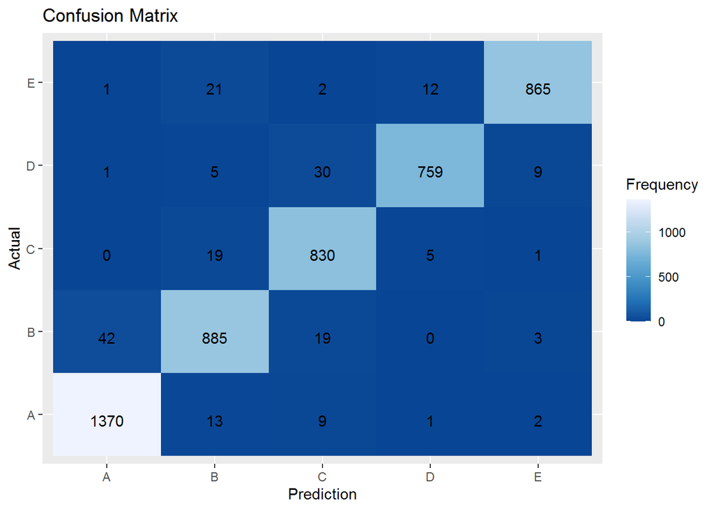

```r
## Plot initial Confusion Matrix
plot1 <- ggplot(data = data,
                mapping = aes(x = predictionGMB,
                              y = Var2))
plot1 <- plot1 + geom_tile(mapping = aes(fill = Freq))
plot1 <- plot1 + geom_text(mapping = aes(label = sprintf("%1.0f", Freq)),
                           vjust = 1)
plot1 <- plot1 + labs(x = "Prediction",
                      y = "Actual",
                      title = "Confusion Matrix")
plot1 <- plot1 + scale_fill_distiller(name = "Frequency")
plot1
```

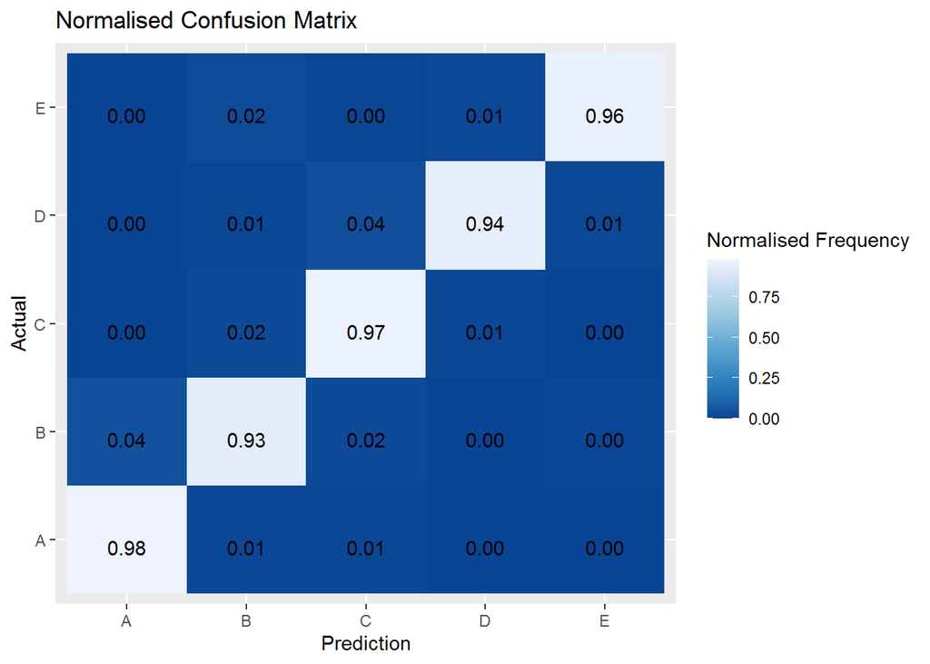

```r
## Plot Normalised Confusion Matrix
plot2 <- ggplot(data = dataPerCent,
                mapping = aes(x = predictionGMB,
                              y = Var2))
plot2 <- plot2 + geom_tile(mapping = aes(fill = Freq))
plot2 <- plot2 + geom_text(mapping = aes(label = sprintf("%1.2f", Freq)),
                           vjust = 1)
plot2 <- plot2 + labs(x = "Prediction",
                      y = "Actual",
                      title = "Normalised Confusion Matrix")
plot2 <- plot2 + scale_fill_distiller(name = "Normalised Frequency")
plot2
```

## Discussion of Results

The corss-validation exercise demostrates that the model predicts which class of the weight lifting exercise was actually carried out with a high degree of accuracy - an overall accuracy of 0.9602365. There are very few false positives and false negatives - therefore the out of sample error is low (0.0397635).

Finally the model is tested against the original test data set of 20 data points as the final test. This is outputted as a dataframe to show which prediction answers which question for the quiz.

```r
predTest <- predict(modelFit, testdata)
predTest <- data.frame(predTest)
predTest
```

```
##    predTest
## 1         B
## 2         A
## 3         B
## 4         A
## 5         A
## 6         E
## 7         D
## 8         B
## 9         A
## 10        A
## 11        B
## 12        C
## 13        B
## 14        A
## 15        E
## 16        E
## 17        A
## 18        B
## 19        B
## 20        B
```